# file_ingestion_schema_validation

[figure not shown]

## Task:

- Take any csv/text file of 2+ GB of your choice. --- (You can do this assignment on Google colab)
- Read the file ( Present approach of reading the file )
- Try different methods of file reading eg: Dask, Modin, Ray, pandas and present your findings in term of computational efficiency
- Perform basic validation on data columns : eg: remove special character , white spaces from the col name
- As you already know the schema hence create a YAML file and write the column name in YAML file. --define separator of  
  read and write file, column name in YAML
- Validate number of columns and column name of ingested file with YAML.
- Write the file in pipe separated text file (|) in gz format.
- Create a summary of the file:

  Total number of rows,

  total number of columns

  file size

# Data Ingestion sample code walkthrough

> Create a utility file

> Config file creation

> Data ingestion pipeline

#### Name: Mario Rodrigues Peres

#### Batch code: LISUM19

#### Submission date: March 26th, 2023

#### Submitted to: Glacier Data Scientist Internship

I executed this jupyter notebook in a MacBook Pro 8GB and I had some trouble reading the files consecutively. Therefore, it is advised to restart the kernel after each file is loaded because they take a lot of space in the memory of the computer.

In the first part, it is presented a reading test using four different methods, which should be run one by one as explained before. In order to create the yaml and python files, and run the validation steps, this jupyter notebook can be started from step 2.

*Dataset Sumary*

## 1. Test: reading a 2GB file using different methods of file reading

An experiment to test the read csv functions of the pakcages pandas, moding, dask and ray was performed and the time to load measured.

In order to run this jupyter notebook, especially to make the test, it is advised to restart the kernel after the file is loaded using any of the files because it takes a lot of space in the memory of the computer and the following scripts many not run accordingly depending on the configuration of your machine.

In this machine, each test was performed after restarting the kernel but the results of each test can be seen in figures presented right after each test part presented in this document.

#### Dask Dataframe

```python
# Loading packages
import datetime as dt
import dask.dataframe as dd
```

```python
# Testing the time needed to read the flights.csv file using dask dataframe
start_time = dt.datetime.now()
df_dd = dd.read_csv("flights.csv", dtype={'CANCELLATION_CODE': 'object'})
print(dt.datetime.now() - start_time)
```

```python
# Testing the time to read the first rows of the dataframe
start_time = dt.datetime.now()
print(df_dd.head(1))
print("\n")
print(dt.datetime.now() - start_time)
```

```python
# Testing the time to check the size of the dataframe
start_time = dt.datetime.now()
print(len(df_dd))
print(dt.datetime.now() - start_time)
```

#### Results of large dataset reading test using dask dataframe

The time to process the reading of the dataset, displaying the first row and displaying the length of the dataframe were measured separately.

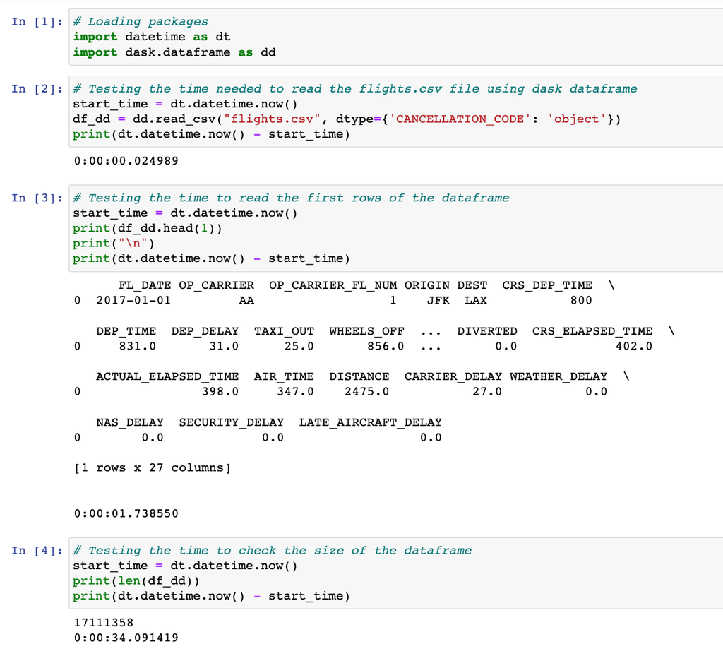

```python
from IPython.display import Image, display
display(Image("images/Image1.jpg"))
```

#### Ray

```python
import datetime as dt
import ray
```

```python
# Testing the time needed to read the flights.csv file using ray
start_time = dt.datetime.now()
df_ray = ray.data.read_csv("flights.csv")
print(dt.datetime.now() - start_time)
```

```python
# Testing the time to read the first rows of the dataframe
start_time = dt.datetime.now()
print(df_ray.show(1))
print(dt.datetime.now() - start_time)
```

```python
# Testing the time to check the size of the dataframe
start_time = dt.datetime.now()
print(df_ray.count())
print(dt.datetime.now() - start_time)
```

#### Results of large dataset reading test using ray

The time to process the reading of the dataset, displaying the first row and displaying the length of the dataframe were measured separately.

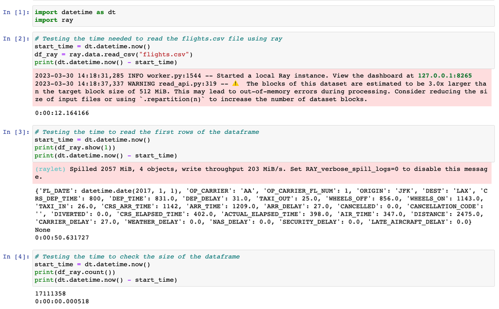

```python
from IPython.display import Image, display
display(Image("images/Image2.jpg"))
```

#### Modin

```python
import datetime as dt
import modin.pandas as mpd
```

```python
# Testing the time needed to read the flights.csv file using modin
start_time = dt.datetime.now()
df_mpd = mpd.read_csv("flights.csv")
print(dt.datetime.now() - start_time)
```

```python
# Testing the time to read the first rows of the dataframe
start_time = dt.datetime.now()
print(df_mpd.head(1))
print(dt.datetime.now() - start_time)
```

```python
# Testing the time to check the size of the dataframe
start_time = dt.datetime.now()
print(len(df_mpd))
print(dt.datetime.now() - start_time)
```

#### Results of large dataset reading test using modin

The time to process the reading of the dataset, displaying the first row and displaying the length of the dataframe were measured separately.

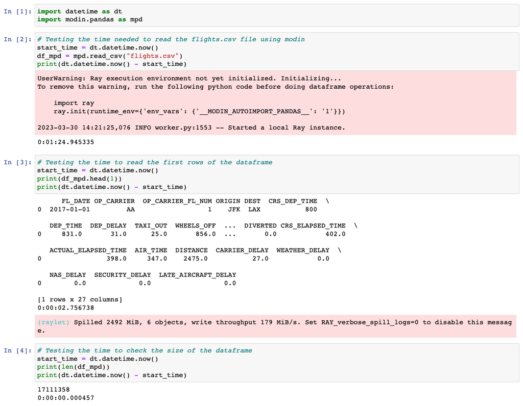

```python
from IPython.display import Image, display
display(Image("images/Image3.jpg"))
```

#### Pandas

```python
import datetime as dt
import pandas as pd
```

```python
# Testing the time needed to read the flights.csv file using pandas
start_time = dt.datetime.now()
df_pd = pd.read_csv("flights.csv")
print(dt.datetime.now() - start_time)
```

```python
# Testing the time to read the first rows of the dataframe
start_time = dt.datetime.now()
print(df_pd.head(1))
print(dt.datetime.now() - start_time)
```

```python
# Testing the time to check the size of the dataframe
start_time = dt.datetime.now()
print(len(df_pd))
print(dt.datetime.now() - start_time)
```

#### Results of large dataset reading test using pandas

The time to process the reading of the dataset, displaying the first row and displaying the length of the dataframe were measured separately.

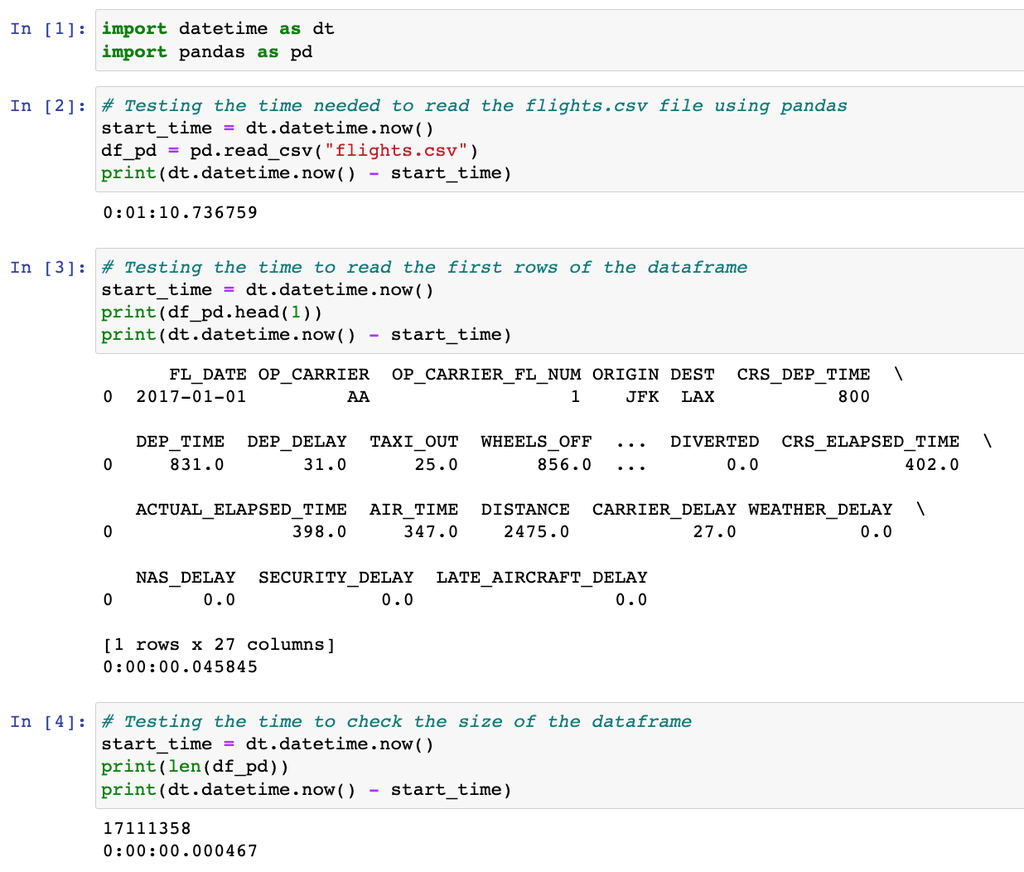

```python
from IPython.display import Image, display
display(Image("images/Image4.jpg"))
```

### Summary of test for reading large csv files using different tools

```python
# Importing pandas
import pandas as pd

# Changing decimal display option of pandas
pd.options.display.float_format = '{:,.3f}'.format

# Creating a dataframe holding the results of the test for comparison
results = pd.DataFrame([[0.025, 1.74, 34.1], [12.2, 50.6, 0.000], [84.9, 2.76, 0.000], [70.7, 0.046, 0.000]],
                       columns=["reading_time", "visualizing_time", "func_time"],
                      index=["dask_dataframe", "ray", "modin", "pandas"])

# Displaying the results in a table
results
```

|  | reading_time | visualizing_time | func_time |
| --- | --- | --- | --- |
| dask_dataframe | 0.025 | 1.740 | 34.100 |
| ray | 12.200 | 50.600 | 0.000 |
| modin | 84.900 | 2.760 | 0.000 |
| pandas | 70.700 | 0.046 | 0.000 |

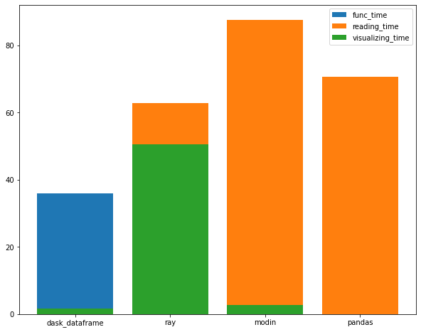

```python
# Importing matplotlib pyplot for graphing the results
import matplotlib.pyplot as plt

# Creating figures to display the graph
fig = plt.figure(figsize=[10,8])

# Ploting the results graph
plt.bar(results.index, results["func_time"]+results["reading_time"]+results["visualizing_time"])
plt.bar(results.index, results["reading_time"]+results["visualizing_time"])
plt.bar(results.index, results["visualizing_time"])

# Inserting legend
plt.legend(["func_time","reading_time","visualizing_time"])
```

#### The fastest reading tool was the Dask Dataframe, however, the fastest tool to perform data processing was pandas. Therefore, let's use the traditional pandas to read the file to complete the tasks of the following steps.

## 2. Creating the file.yaml and the csvutility.py files

Firstly, only the first 100 rows of the flights file was read, so that all the columns' names could be checked and necessary changes performed. Following the necessary changes and with the information of the table schema, the file.yaml was created. After that, the csvutility.py script was developed.

```python
# Loading packages
import pandas as pd
import re
```

```python
# Loading the dataset flights into the dataframe df
df = pd.read_csv("flights.csv", nrows=100)

# Displaying the first registers of the dataframe
df.head()
```

|  | FL_DATE | OP_CARRIER | OP_CARRIER_FL_NUM | ORIGIN | DEST | CRS_DEP_TIME | DEP_TIME | DEP_DELAY | TAXI_OUT | WHEELS_OFF | ... | DIVERTED | CRS_ELAPSED_TIME | ACTUAL_ELAPSED_TIME | AIR_TIME | DISTANCE | CARRIER_DELAY | WEATHER_DELAY | NAS_DELAY | SECURITY_DELAY | LATE_AIRCRAFT_DELAY |
| --- | --- | --- | --- | --- | --- | --- | --- | --- | --- | --- | --- | --- | --- | --- | --- | --- | --- | --- | --- | --- | --- |
| 0 | 2017-01-01 | AA | 1 | JFK | LAX | 800 | 831.000 | 31.000 | 25.000 | 856.000 | ... | 0.000 | 402.000 | 398.000 | 347.000 | 2,475.000 | 27.000 | 0.000 | 0.000 | 0.000 | 0.000 |
| 1 | 2017-01-01 | AA | 2 | LAX | JFK | 900 | 934.000 | 34.000 | 34.000 | 1,008.000 | ... | 0.000 | 327.000 | 335.000 | 289.000 | 2,475.000 | 34.000 | 0.000 | 8.000 | 0.000 | 0.000 |
| 2 | 2017-01-01 | AA | 4 | LAX | JFK | 1130 | 1,221.000 | 51.000 | 20.000 | 1,241.000 | ... | 0.000 | 328.000 | 319.000 | 284.000 | 2,475.000 | 7.000 | 0.000 | 0.000 | 0.000 | 35.000 |
| 3 | 2017-01-01 | AA | 5 | DFW | HNL | 1135 | 1,252.000 | 77.000 | 19.000 | 1,311.000 | ... | 0.000 | 517.000 | 537.000 | 513.000 | 3,784.000 | 77.000 | 0.000 | 20.000 | 0.000 | 0.000 |
| 4 | 2017-01-01 | AA | 6 | OGG | DFW | 1855 | 1,855.000 | 0.000 | 16.000 | 1,911.000 | ... | 0.000 | 425.000 | 467.000 | 440.000 | 3,711.000 | 0.000 | 0.000 | 42.000 | 0.000 | 0.000 |

5 rows × 27 columns

```python
# Checking the type of the variables
df.info()
```

```
<class 'pandas.core.frame.DataFrame'>
RangeIndex: 100 entries, 0 to 99
Data columns (total 27 columns):
 #   Column               Non-Null Count  Dtype
---  ------               --------------  -----
 0   FL_DATE              100 non-null    object
 1   OP_CARRIER           100 non-null    object
 2   OP_CARRIER_FL_NUM    100 non-null    int64
 3   ORIGIN               100 non-null    object
 4   DEST                 100 non-null    object
 5   CRS_DEP_TIME         100 non-null    int64
 6   DEP_TIME             99 non-null     float64
 7   DEP_DELAY            99 non-null     float64
 8   TAXI_OUT             99 non-null     float64
 9   WHEELS_OFF           99 non-null     float64
```

[output cut: 19 more lines]

```python
# Checking the unique values for all variables
[df[col].unique() for col in df.columns]
```

```
[array(['2017-01-01'], dtype=object),
 array(['AA'], dtype=object),
 array([  1,   2,   4,   5,   6,   7,   8,   9,  10,  12,  14,  15,  16,
         19,  20,  21,  22,  23,  25,  28,  29,  30,  31,  32,  33,  34,
         36,  37,  38,  39,  40,  41,  43,  46,  50,  51,  52,  53,  54,
         55,  56,  58,  59,  60,  61,  64,  65,  66,  67,  68,  69,  70,
         71,  72,  73,  74,  81,  82,  83,  84,  85,  86,  87,  88,  89,
         92,  94,  95,  96,  97,  98, 100, 101, 102, 103, 104, 106, 108,
        109, 110, 111, 112, 113, 116, 117, 118, 119, 123, 126, 130, 132,
        133, 134, 139, 140]),
 array(['JFK', 'LAX', 'DFW', 'OGG', 'HNL', 'SFO', 'ORD', 'MIA', 'IAH',
        'BOS', 'DTW', 'MSP', 'STL', 'MCO', 'KOA', 'LAS', 'MEM', 'PDX',
        'SEA', 'SAN', 'TUS', 'CLT', 'SJC', 'DCA', 'PHX', 'ATL'],
       dtype=object),
 array(['LAX', 'JFK', 'HNL', 'DFW', 'OGG', 'SFO', 'LAS', 'BOS', 'MIA',
        'MCO', 'ORD', 'DTW', 'STL', 'DCA', 'TPA', 'KOA', 'MEM', 'DEN',
        'SEA', 'PDX', 'LGA', 'SLC', 'SAN', 'IAH', 'CLT', 'SJC', 'EWR'],
       dtype=object),
 array([ 800,  900, 1130, 1135, 1855,  940, 1838,  700, 2100, 2313,  825,
        1305, 1530, 1900, 1340, 2215, 1705, 2200, 1255, 2355,  822, 1430,
        1245, 1001, 1840, 1348, 2145, 1911, 1335, 1110, 1529, 1558, 1136,
        1645, 1240, 1508, 1400, 1850, 2305, 1715, 1730,  705, 1320,  730,
        1625,  855, 2022,  845,  813, 1853, 1728, 1934, 1905, 1800, 2050,
        1735, 1955, 1650, 1615, 2105,  745, 1725,  905, 1719, 1322, 1300,
        1636, 2117, 1350,  957, 1940,  945, 1700, 1425, 2029, 2053, 1810,
        1215, 1825, 2040,  810, 1859]),
 array([ 831.,  934., 1221., 1252., 1855., 1619., 1903.,  656., 2100.,
        1130., 2350.,  824., 1259.,  856., 1525., 1922., 1346., 2225.,
        1707., 2202., 1251.,   25.,  821., 1454., 1306.,  958., 1846.,
        1404., 2159., 1905., 1109., 1523., 1608., 1150., 1644., 1237.,
        1517., 1356., 1857., 1602., 2352., 1801., 1733.,  928., 1343.,
        1532.,  725., 1631., 2018., 1007.,  810., 1933., 1835., 2022.,
        1902.,  808., 1759., 2048., 1726., 1950.,  756., 1611., 2153.,
         746., 1724.,  939., 1736., 1324., 1335., 2112., 1110., 1342.,
        1728.,   nan,  659., 1957.,  955., 1718., 2140.,  658., 1143.,
         910., 1929., 1217., 2206., 1658., 2037.,  820., 1246., 1910.]),
 array([ 31.,  34.,  51.,  77.,   0., 399.,  25.,  -4.,  -5.,  37.,  -1.,
         -6.,  22.,   6.,  10.,   2.,  30.,  24.,  21.,  -3.,  16.,  14.,
         29.,   9.,   7.,   4.,  47.,  46.,   3., 143.,  23., 397.,  82.,
         40.,  67.,  48.,   8.,  -2.,  -9.,   1.,  17.,  35.,  -8.,  -7.,
```

[output cut: 81 more lines]

```
        213.]),
 array([2475., 3784., 3711., 2586., 2486., 1514., 1258., 2556., 1464.,
         964.,  192.,  867., 1846.,  986.,  334.,  550., 2311., 1012.,
        1005., 2504., 1121., 1089., 2342., 1235.,  236.,  431.,  641.,
        2422.,  187., 1739., 1096.,  989., 2446., 1437.,  541., 1438.,
         213., 2153., 1744., 1389.,  740., 1372., 2724.,  594.]),
 array([ 27.,  34.,   7.,  77.,   0., 394.,  25.,  nan,  22.,   2.,  19.,
          3.,  46., 143.,  15., 397.,  70.,   1.,  48.,  17.,  33.,   5.,
         56.,  28.]),
 array([ 0., nan]),
 array([ 0.,  8., 20., 42., 33., nan,  9., 23., 16., 17.,  3., 14.,  6.,
        15., 10.,  7., 35.]),
 array([ 0., nan]),
 array([  0.,  35.,  nan,  13.,  18.,   8.,  21.,  57.,  30.,  19.,  26.,
        105.,  59.,  39., 187.])]
```

Checking the variables, it was clear that we should change the type of the variable FL_DATE to datetime and the type of the variables CANCELLED and DIVERTED to object (str). These last two variables represent yes or no.

```python
# Changing the data type of three variables as mentioned above
df["FL_DATE"] = pd.to_datetime(df["FL_DATE"])
df["CANCELLED"] = df["CANCELLED"].astype(str)
df["DIVERTED"] = df["DIVERTED"].astype(str)
```

```python
# Re-checking the type of these three variables again
df[["FL_DATE", "CANCELLED", "DIVERTED"]].info()
```

```
<class 'pandas.core.frame.DataFrame'>
RangeIndex: 100 entries, 0 to 99
Data columns (total 3 columns):
 #   Column     Non-Null Count  Dtype
---  ------     --------------  -----
 0   FL_DATE    100 non-null    datetime64[ns]
 1   CANCELLED  100 non-null    object
 2   DIVERTED   100 non-null    object
dtypes: datetime64[ns](1), object(2)
memory usage: 2.5+ KB
```

```python
# Checking the name of the columns
df.columns
```

```
Index(['FL_DATE', 'OP_CARRIER', 'OP_CARRIER_FL_NUM', 'ORIGIN', 'DEST',
       'CRS_DEP_TIME', 'DEP_TIME', 'DEP_DELAY', 'TAXI_OUT', 'WHEELS_OFF',
       'WHEELS_ON', 'TAXI_IN', 'CRS_ARR_TIME', 'ARR_TIME', 'ARR_DELAY',
       'CANCELLED', 'CANCELLATION_CODE', 'DIVERTED', 'CRS_ELAPSED_TIME',
       'ACTUAL_ELAPSED_TIME', 'AIR_TIME', 'DISTANCE', 'CARRIER_DELAY',
       'WEATHER_DELAY', 'NAS_DELAY', 'SECURITY_DELAY', 'LATE_AIRCRAFT_DELAY'],
      dtype='object')
```

```python
# Changing all the characters of the name of columns to upper case
df.columns = df.columns.str.upper()
```

```python
# Replacing any other special characteres to '_'
df.columns = df.columns.str.replace('[^\w]','_',regex=True)
```

```python
# Stripping the name of the columns based on the '_', which was supposed to replace white spaces
# at the begin and end of each column name
df.columns = list(map(lambda x: x.strip('_'), list(df.columns)))
```

```python
# Defining a function to support the formatting of the name of the columns
def replacer(string, char):
    pattern = char + '{2,}'
    string = re.sub(pattern, char, string)
    return string
```

```python
# Applying function created in the previous cell to perform last changes in the name of the columns
df.columns = list(map(lambda x: replacer(x,'_'), list(df.columns)))
df.columns
```

```
Index(['FL_DATE', 'OP_CARRIER', 'OP_CARRIER_FL_NUM', 'ORIGIN', 'DEST',
       'CRS_DEP_TIME', 'DEP_TIME', 'DEP_DELAY', 'TAXI_OUT', 'WHEELS_OFF',
       'WHEELS_ON', 'TAXI_IN', 'CRS_ARR_TIME', 'ARR_TIME', 'ARR_DELAY',
       'CANCELLED', 'CANCELLATION_CODE', 'DIVERTED', 'CRS_ELAPSED_TIME',
       'ACTUAL_ELAPSED_TIME', 'AIR_TIME', 'DISTANCE', 'CARRIER_DELAY',
       'WEATHER_DELAY', 'NAS_DELAY', 'SECURITY_DELAY', 'LATE_AIRCRAFT_DELAY'],
      dtype='object')
```

### 2.1. Creating the YAML file (file.yaml)

Filling up the yaml file using the name of the columns previously processed

```python
%%writefile file.yaml
file_type: csv
dataset_name: testfile
file_name: flights
table_name: edsurv
inbound_delimiter: ","
outbound_delimiter: "|"
skip_leading_rows: 1
output_file: output_file
output_file_format: txt
compress_type: gz
columns:
    - FL_DATE
    - OP_CARRIER
    - OP_CARRIER_FL_NUM
    - ORIGIN
    - DEST
    - CRS_DEP_TIME
    - DEP_TIME
    - DEP_DELAY
    - TAXI_OUT
    - WHEELS_OFF
    - WHEELS_ON
    - TAXI_IN
    - CRS_ARR_TIME
    - ARR_TIME
    - ARR_DELAY
    - CANCELLED
    - CANCELLATION_CODE
    - DIVERTED
    - CRS_ELAPSED_TIME
    - ACTUAL_ELAPSED_TIME
    - AIR_TIME
    - DISTANCE
    - CARRIER_DELAY
    - WEATHER_DELAY
    - NAS_DELAY
    - SECURITY_DELAY
    - LATE_AIRCRAFT_DELAY
```

```
Writing file.yaml
```

### 2.2. Creating the csvutility file (csvutility.py)

```python
%%writefile csvutility.py
import logging
import os
import subprocess
import yaml
import pandas as pd
import datetime
import gc
import re


################
# File Reading #
################

def read_config_file(filepath):
    with open(filepath, 'r') as stream:
        try:
            return yaml.safe_load(stream)
        except yaml.YAMLError as exc:
            logging.error(exc)


def replacer(string, char):
    pattern = char + '{2,}'
    string = re.sub(pattern, char, string)
    return string

def col_header_val(df, table_config):
    '''
    replace whitespaces in the column
    and standardized column names
    '''
    df.columns = df.columns.str.upper()
    df.columns = df.columns.str.replace('[^\w]','_',regex=True)
    df.columns = list(map(lambda x: x.strip('_'), list(df.columns)))
    df.columns = list(map(lambda x: replacer(x,'_'), list(df.columns)))
    expected_col = list(map(lambda x: x.upper(),  table_config['columns']))
    expected_col.sort()
    df.columns =list(map(lambda x: x.upper(), list(df.columns)))
    columns_index = list(df.columns)
    df = df.reindex(sorted(df.columns), axis=1)
    if len(df.columns) == len(expected_col) and list(expected_col) == list(df.columns):
        print("column name and column length validation passed")
        df = df.reindex(columns=columns_index)
        return 1

    else:
        print("column name and column length validation failed")
        mismatched_columns_file = list(set(df.columns).difference(expected_col))
        print("Following File columns are not in the YAML file",mismatched_columns_file)
        missing_YAML_file = list(set(expected_col).difference(df.columns))
        print("Following YAML columns are not in the file uploaded",missing_YAML_file)
        logging.info(f'df columns: {df.columns}')
        logging.info(f'expected columns: {expected_col}')
        return 0

def file_summary(df):
    '''
    create a summary of the loaded dataframe, including the number of rows,
    number of columns and the size of the file
    '''
    nc = len(df.columns)
    nr = len(df.index)
    mem = sum(df.memory_usage())
    print("\nThis dataset presents {} columns (variables) and {} rows (registers).".format(nc, nr))

    if mem < 1000:
        print("\nThe file size is: {} bytes".format(mem))
    elif mem < 1000000:
        print("\nThe file size is: {} KB".format(round(mem/1000, 1)))
    elif mem < 1000000000:
        print("\nThe file size is: {} MB".format(round(mem/1000000, 1)))
    elif mem < 1000000000000:
        print("\nThe file size is: {} GB".format(round(mem/1000000000, 1)))
    return 1

def save_pipe_txtgz_file(df, table_config):

    output = "data/" + table_config["output_file"] + "." + table_config["output_file_format"] + "." + table_config["compress_type"]
    df.to_csv(output, index=False, sep="|", header=True, chunksize=5000, compression="gzip")
```

```
Writing csvutility.py
```

### 2.3 Testing the csvutility procedures with 2 datasets

These datasets are modifications of the original dataset but with a much smaller size, as it does not influence the check performed in the columns by the created script. We edited the yaml every time the validation was run because diferent files were used as input.

The first dataset presented columns with the same names but presenting a few spaces and special caracteres, such as: "FL#DATE ", "DISTANCE#$%", " DEST___", "AIR TIME", and "TAXI|IN".

The second dataset presented a few columns with changed names, such as FL_DATE to FL_DATA, DISTANCE to DISTANCA. Moreover, there were added two new columns BOARDING_FEE and COMPANY_NAME.